# The data used is this project is 100% real and is scraped autonomously from different tech publisher websites starting from 1/July/2026.

### Business Requirements and KPIs:

- Requirement 1: **Monitor Publishing Activity**

Business Need: Understand How much Technology news is being published over time.

Questions:

1. How many articles are published each day ?
2. Which day had the highest publishing activity ?
3. Is article volume increasing or decreasing ?
- Requirement 2: **Evaluate Publisher Performance**

Business Need: Compare Publishers to understand who contributes the most content.

Questions:

1. Which Publisher publishes the most articles ?
2. Which Publisher coverst the widest range of categories ?
3. Which Publisher publishes the longest articles ?
- Requirement 3: **Analyze Technology Categoreis**

Business Need: Discover which technology domains are receiving the most attention.

Questions:

1. Which Categories dominate the news ?
2. Which categories are growing ?
3. Which categories are rarely covered ?
- Requirement 4: **Track companies and Technology**

Business need: Measure Industry attention

Questions:

1. Which companies are mentioned most often ?
2. Which Technologies appear most frequently ?
3. Which companies are trending this month ?
- Requirement 5: **Measure Content Characteristics**

Business Need: Understand article quality and reading effort

Questions:

1. Average Article length.
2. Average reading time.
3. Distribution of article length.
4. Longest and shortest articles.
- Requirement 6: **Author Insights**

Business Need: Identify the most active contributors:

Questions:

1. Most active authors.
2. Average article per authore
3. Publishers with the largest author base

### KPIs:

- Total Articles
- Active Publishers
- Total Authors
- Total Categories
- Average Reading Time
- Average word count
- Articles Published Today
- Most Active Publishers
- Most Popular Category
- Most Mentioned Company
- Most Mentioned Technology

### Data Understanding:

### Excel Analytics:

**As the Data from the ETL is push directly to cloud database, we are fetching the data into Excel dynamically using the ODBC DSN.**

#### **Articles table:**

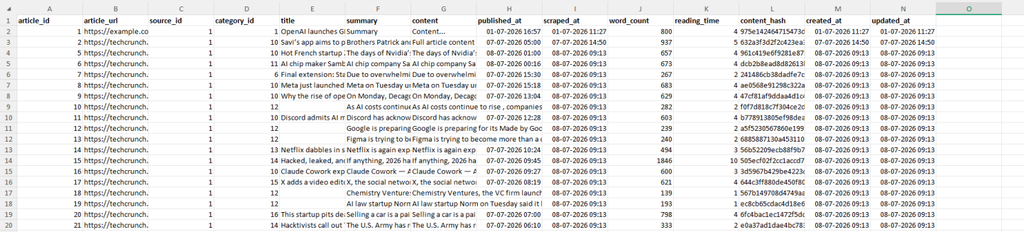

- **article_id** – Unique identifier assigned to each news article.
- **article_url** – Original web link of the news article.
- **source_id** – Identifier representing the news source (e.g., TechCrunch, The Verge).
- **category_id** – Identifier representing the category assigned to the article.
- **title** – Headline of the news article.
- **summary** – Brief overview of the article content.
- **content** – Complete text extracted from the news article.
- **published_at** – Date and time when the article was originally published.
- **scraped_at** – Date and time when the article was collected by the ETL pipeline.
- **word_count** – Total number of words in the article.
- **reading_time** – Estimated reading time of the article (in minutes).
- **content_hash** – Unique hash generated from the article content to detect duplicates.
- **created_at** – Timestamp indicating when the record was inserted into the database.
- **updated_at** – Timestamp indicating when the record was last updated.

#### **Authors Table:**

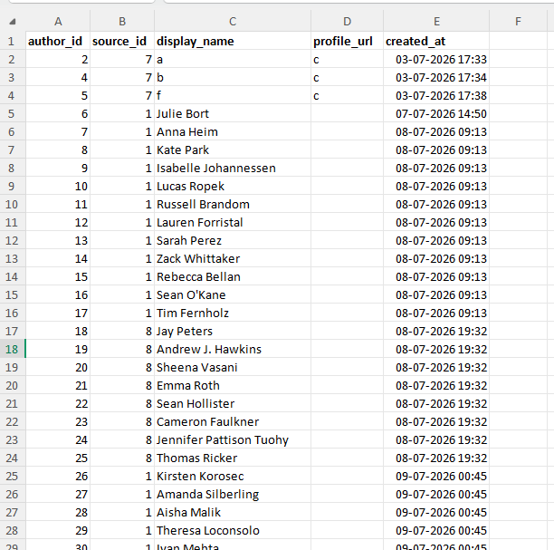

- **author_id** – Unique identifier assigned to each author.
- **source_id** – Identifier of the news source the author belongs to.
- **display_name** – Name of the author as displayed on the news website.
- **profile_url** – Link to the author's profile page, if available.
- **created_at** – Timestamp indicating when the author record was created in the database.

#### **Categories Tables:**

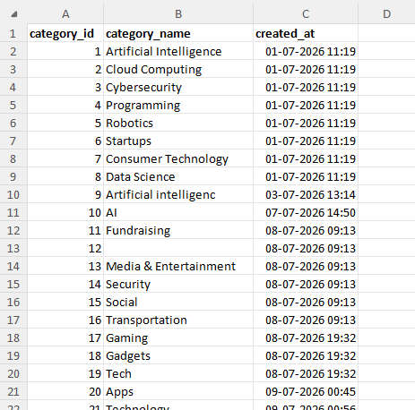

- category_id – Unique identifier assigned to each category.
- category_name – Name of the category assigned to news articles (e.g., AI, Robotics, Cybersecurity).
- created_at – Timestamp indicating when the category record was created in the database.

#### **Sources Table:**

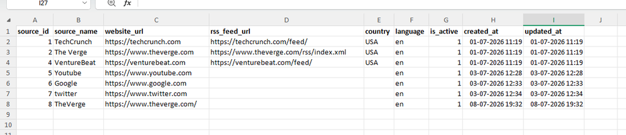

- **source_id** – Unique identifier assigned to each news source.
- **source_name** – Name of the news source (e.g., TechCrunch, The Verge).
- **website_url** – Official website URL of the news source.
- **rss_feed_url** – RSS feed URL used to fetch the latest articles.
- **country** – Country where the news source is based.
- **language** – Primary language of the news source.
- **is_active** – Indicates whether the news source is currently active in the data collection process (1 = Active, 0 = Inactive).
- **created_at** – Timestamp indicating when the source record was created in the database.
- **updated_at** – Timestamp indicating when the source record was last updated.

#### **Tags Table:**

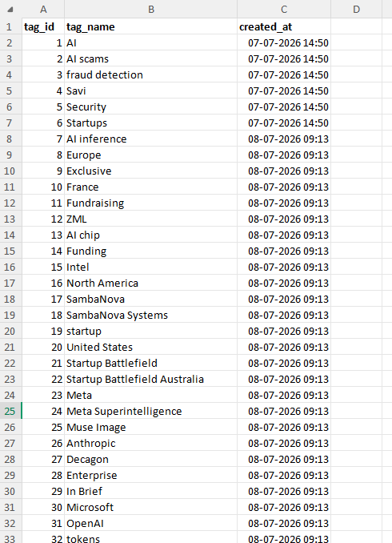

- **tag_id** – Unique identifier assigned to each tag.
- **tag_name** – Keyword or label associated with a news article to describe its topic or subject.
- **created_at** – Timestamp indicating when the tag record was created in the database.
- The Company and Technology table are not used immediately as they dont have any real data. These tables will be populated after the implementation of NLP when we identify the company and Technology names from the content of the articles.

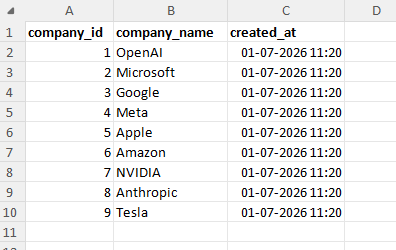

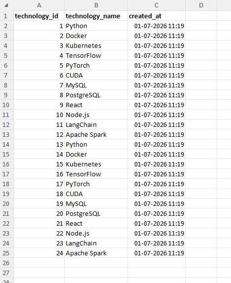

### SQL Analytics:

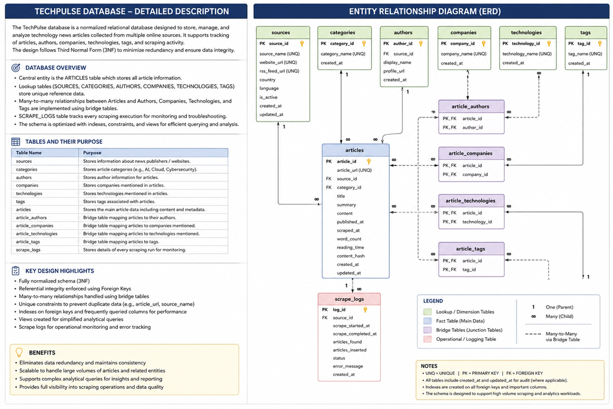

From the Schema we know that:

| Table | Purpose |
| --- | --- |
| `articles` | Main fact table containing article details |
| `sources` | Publishers (TechCrunch, The Verge, etc.) |
| `authors` | Article authors |
| `categories` | Technology categories |
| `companies` | Companies mentioned |
| `technologies` | Technologies mentioned |
| `article_authors` | Bridge table |
| `article_companies` | Bridge table |
| `article_technologies` | Bridge table |

- All of the queries were solved in MySQL Workbench.

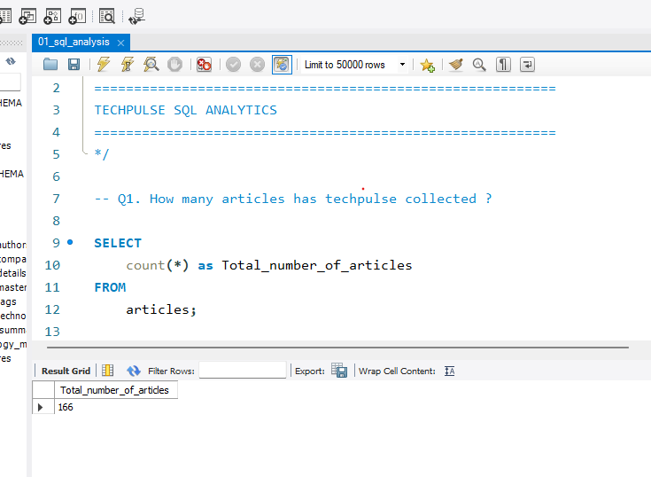

- As of 13-July-2026, There are total 166 articles scraped from 3 different sources.

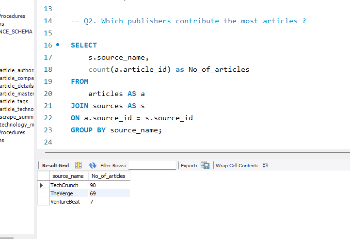

- From the 166 articles TechCrunch contributes the Most number of articles.

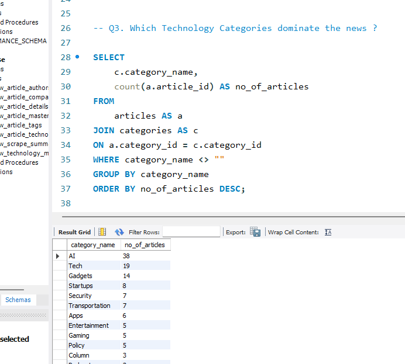

- We can see that the Categories like AI, TECH, Gadgets and Startups dominate the news considerably.

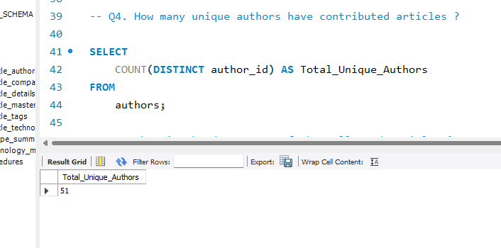

- As of 13/July/2026, there are 51 unique Authors.

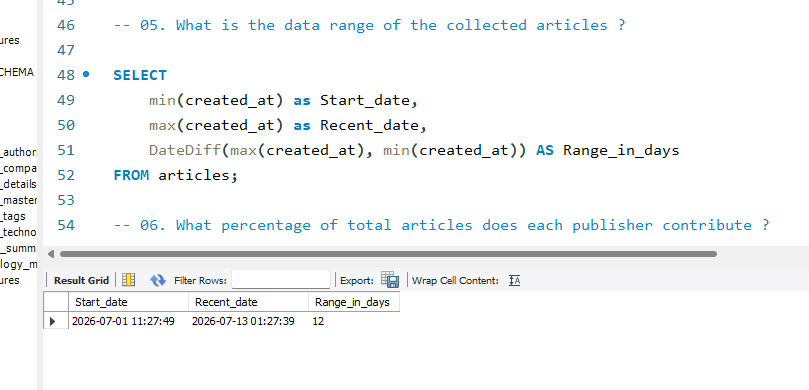

- The scraping project started on 1/July/2026. So the data collected is of about 12 days.

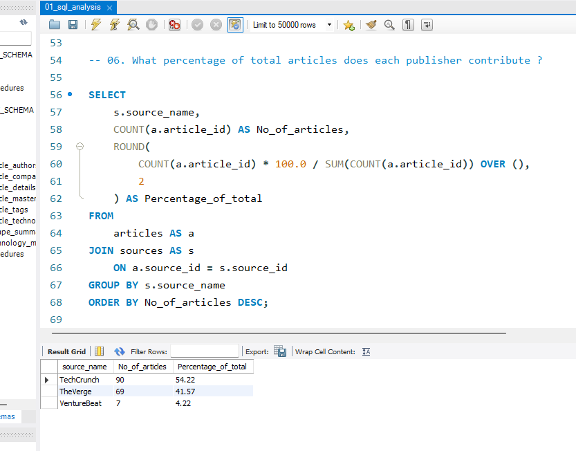

- As we found earlier that TechCrunch contributes to most number of articles, the percentage is almost 55%.

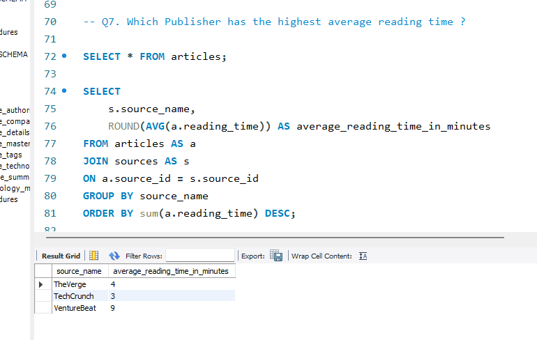

- The Articles of VentureBeat are considerably longer, perhaps time taken in reading them is also more.

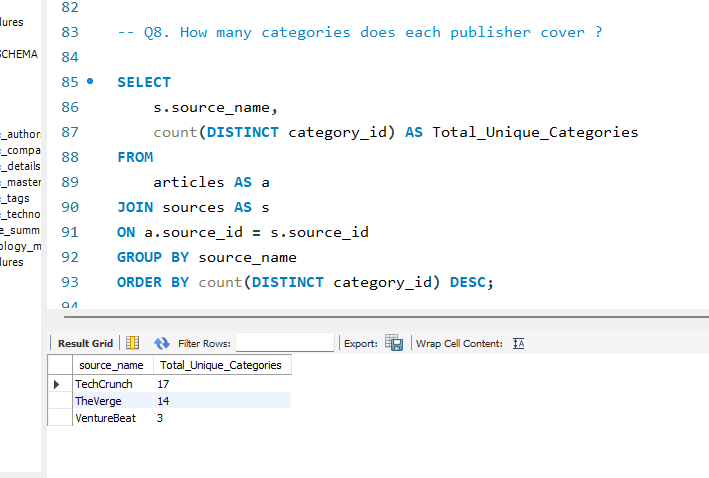

- From the result we found out that TechCrunch covers most numbers of different topics in the Tech News.

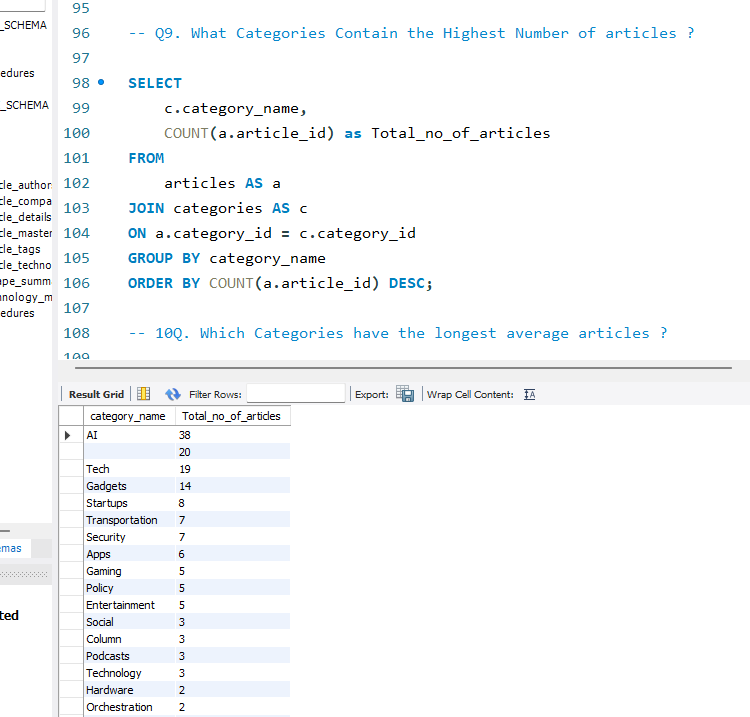

- The same dominant categories are found in more number of articles produced.

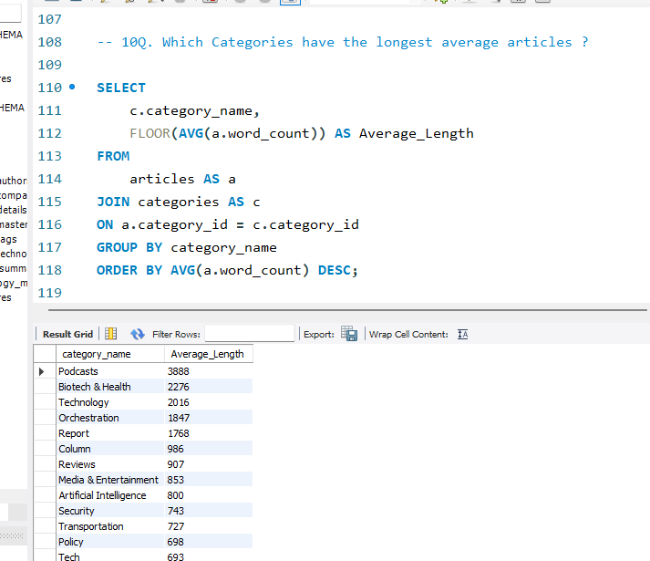

- Podcasts which are deemed to be long-form content predomininantly has most lengthy articles in terms of word count followed by Biotech and Technology.

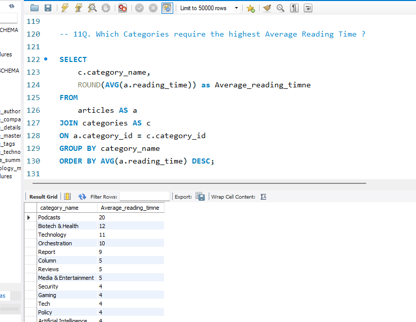

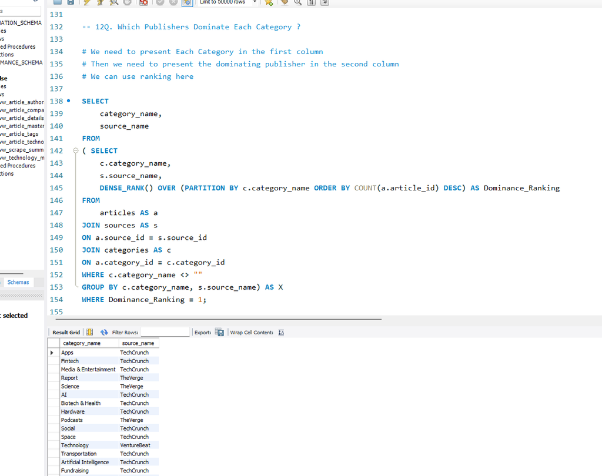

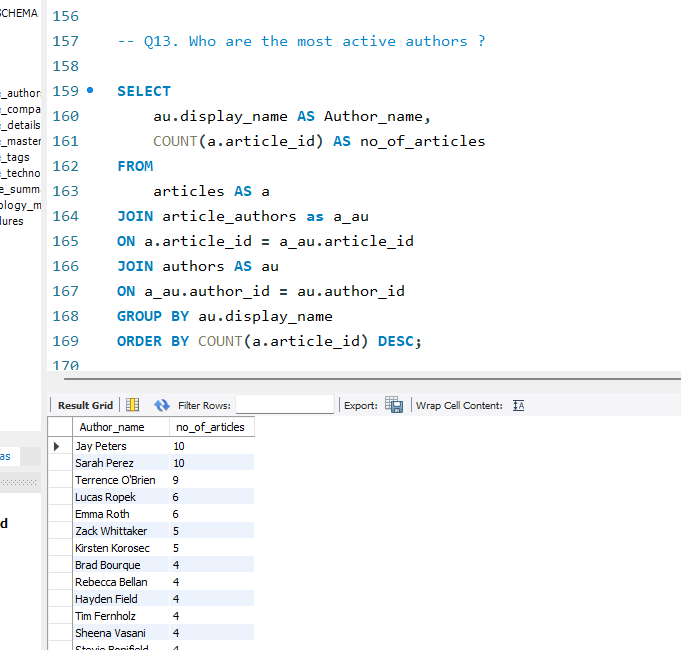

- From the result we found out that Jay Peters, Sarah Perez are most active authors in tech articles followed bt Terrence O'Brien.

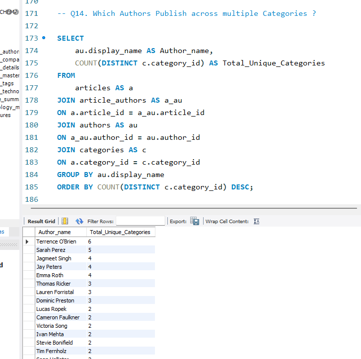

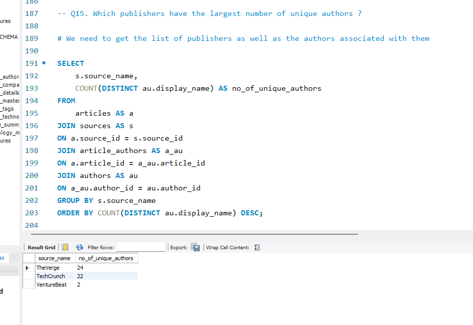

- TheVerge Has the highest number of unique authors.

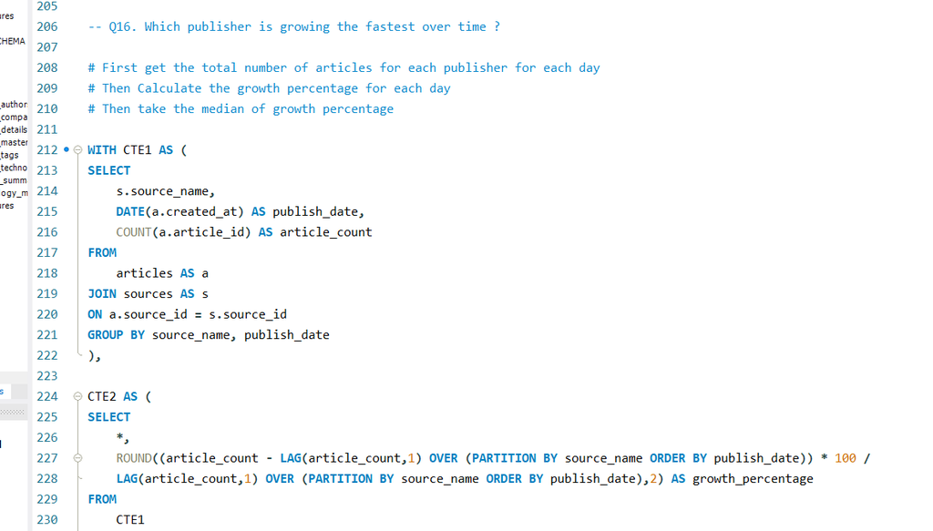

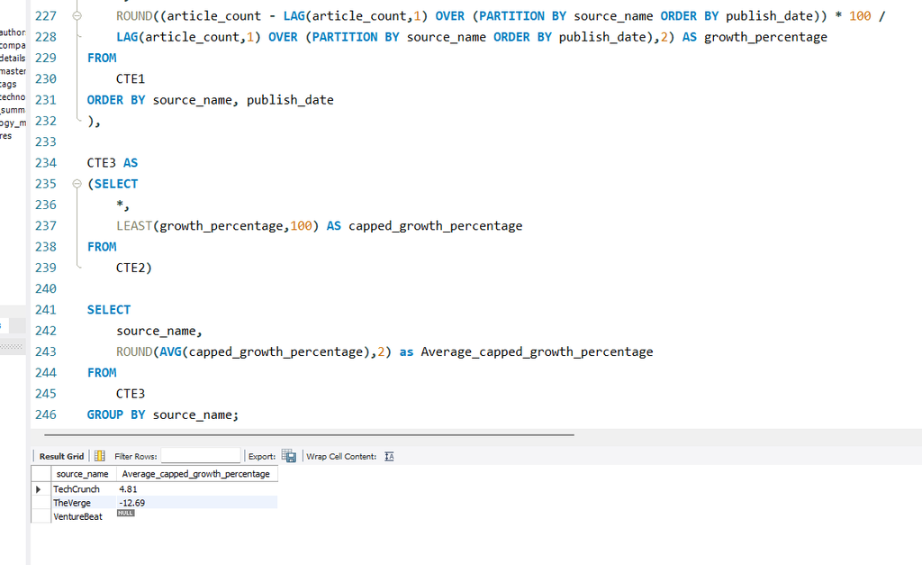

- This was supposed to be calculated using Median. But median is not possible directly in MySQl so the outliers were **capped** and then the average was calculated.
- From the Result we can see clearly that TechCrunch is considerably the faster growing publisher in terms no of articles produced.

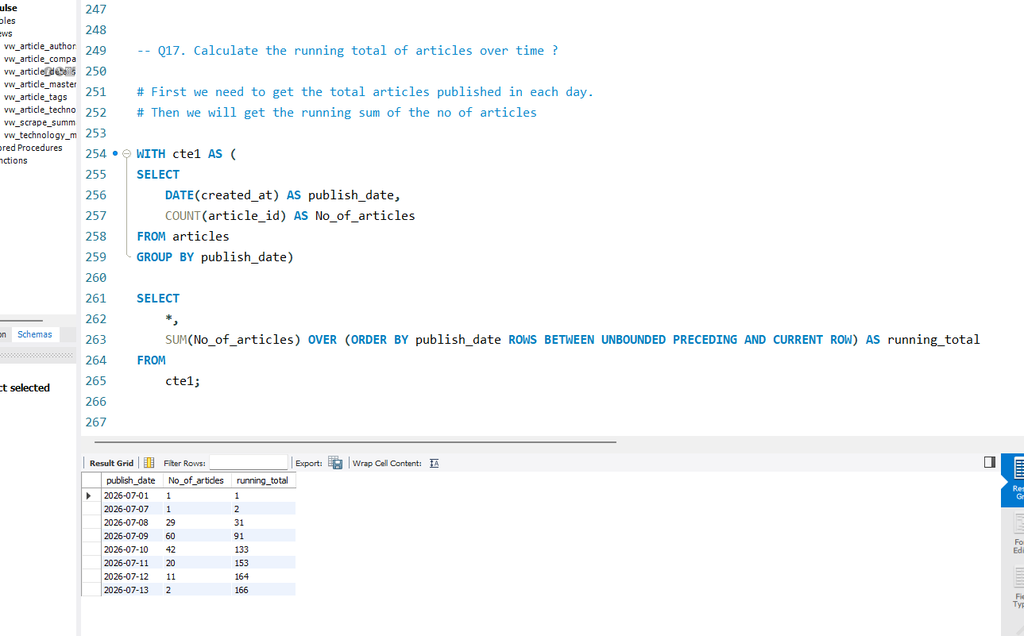

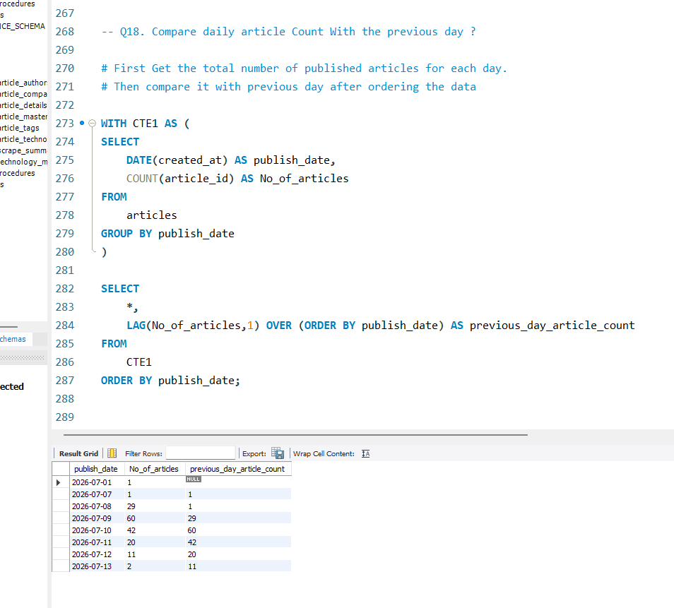

- The I Created Some **VIEWS** for efficient Python Analysis.

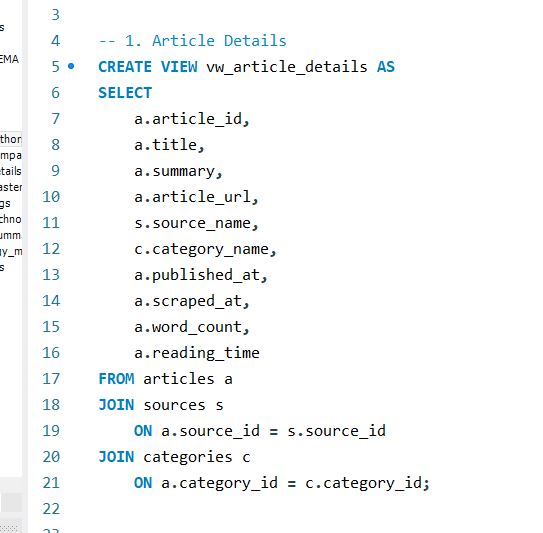

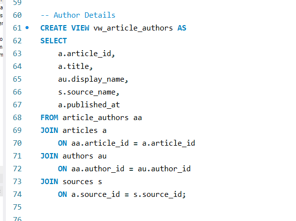

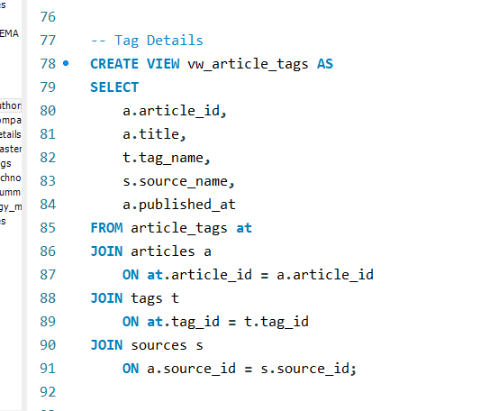

### Python Analytics:

```python
import pandas as pd
import numpy as np
import matplotlib.pyplot as plt
import seaborn as sns
```

```python
!pip install mysql-connector-python
```

```
Downloading mysql_connector_python-9.7.0-cp312-cp312-manylinux_2_28_x86_64.whl (21.7 MB)
   ━━━━━━━━━━━━━━━━━━━━━━━━━━━━━━━━━━━━━━━━ 21.7/21.7 MB 57.0 MB/s eta 0:00:00
```

```python
import mysql.connector

conn = mysql.connector.connect(
    host="gateway01.ap-southeast-1.prod.aws.tidbcloud.com",
    port=4000,
    user="3DB4Dz7zSEiXUhZ.root",
    password="W5akVTcthmfX8rt0",
    database="techpulse"
)

df = pd.read_sql("SELECT * FROM articles", conn)
```

```python
!pip install sqlalchemy pymysql
```

```
Downloading pymysql-1.2.0-py3-none-any.whl (45 kB)
   ━━━━━━━━━━━━━━━━━━━━━━━━━━━━━━━━━━━━━━━━ 45.7/45.7 kB 3.1 MB/s eta 0:00:00
```

```python
from sqlalchemy import create_engine

# "mysql+pymysql://username:password@host:4000/database"

engine = create_engine(
    "mysql+pymysql://3DB4Dz7zSEiXUhZ.root:W5akVTcthmfX8rt0@gateway01.ap-southeast-1.prod.aws.tidbcloud.com:4000/techpulse"
)

df_articles = pd.read_sql("SELECT * FROM vw_article_master;", engine)
df_authors = pd.read_sql("SELECT * FROM vw_article_authors;", engine)
df_tags = pd.read_sql("SELECT * FROM vw_article_tags", engine)
```

### Article Related Analytics:

```python
df_articles.shape
```

```
(166, 19)
```

```python
df_articles.columns
```

```
Index(['article_id', 'title', 'summary', 'article_url', 'source_name',
       'country', 'language', 'category_name', 'published_at',
       'published_date', 'published_year', 'published_month', 'month_name',
       'quarter', 'week_number', 'weekday', 'word_count', 'reading_time',
       'scraped_at'],
      dtype='object')
```

```python
df_articles.head()
```

|  | article_id | title | summary | article_url | source_name | country | language | category_name | published_at | published_date | published_year | published_month | month_name | quarter | week_number | weekday | word_count | reading_time | scraped_at |
| --- | --- | --- | --- | --- | --- | --- | --- | --- | --- | --- | --- | --- | --- | --- | --- | --- | --- | --- | --- |
| 0 | 1 | OpenAI launches GPT-6 | Summary | https://example.com/article1 | TechCrunch | USA | en | Artificial Intelligence | 2026-07-01 16:57:49 | 2026-07-01 | 2026.0 | 7.0 | July | 3.0 | 26.0 | Wednesday | 800 | 4 | 2026-07-01 11:27:49 |
| 1 | 2 | Savi’s app aims to protect consumers from real... | Brothers Patrick and Ryan Coughlin, each with ... | https://techcrunch.com/2026/07/07/savis-app-ai... | TechCrunch | USA | en | AI | 2026-07-07 05:00:00 | 2026-07-07 | 2026.0 | 7.0 | July | 3.0 | 27.0 | Tuesday | 937 | 5 | 2026-07-07 14:50:13 |
| 2 | 5 | Hot French startup ZML releases free product t... | The days of Nvidia’s unparalleled market domin... | https://techcrunch.com/2026/07/08/hot-french-s... | TechCrunch | USA | en | AI | 2026-07-08 01:00:00 | 2026-07-08 | 2026.0 | 7.0 | July | 3.0 | 27.0 | Wednesday | 657 | 4 | 2026-07-08 09:13:03 |
| 3 | 6 | AI chip maker SambaNova raises $1B at $11B val... | AI chip company SambaNova Systems has raised $... | https://techcrunch.com/2026/07/08/sambanova-dr... | TechCrunch | USA | en | Fundraising | 2026-07-08 00:16:00 | 2026-07-08 | 2026.0 | 7.0 | July | 3.0 | 27.0 | Wednesday | 673 | 4 | 2026-07-08 09:13:03 |
| 4 | 7 | Final extension: Startup Battlefield Australia... | Due to overwhelming interest, we’ve extended a... | https://techcrunch.com/2026/07/07/final-extens... | TechCrunch | USA | en | Startups | 2026-07-07 15:30:00 | 2026-07-07 | 2026.0 | 7.0 | July | 3.0 | 27.0 | Tuesday | 267 | 2 | 2026-07-08 09:13:03 |

```python
df_articles.info()
```

```
<class 'pandas.core.frame.DataFrame'>
RangeIndex: 166 entries, 0 to 165
Data columns (total 19 columns):
 #   Column           Non-Null Count  Dtype
---  ------           --------------  -----
 0   article_id       166 non-null    int64
 1   title            166 non-null    object
 2   summary          166 non-null    object
 3   article_url      166 non-null    object
 4   source_name      166 non-null    object
 5   country          97 non-null     object
 6   language         166 non-null    object
 7   category_name    166 non-null    object
 8   published_at     146 non-null    datetime64[ns]
 9   published_date   146 non-null    object
 10  published_year   146 non-null    float64
 11  published_month  146 non-null    float64
 12  month_name       146 non-null    object
 13  quarter          146 non-null    float64
 14  week_number      146 non-null    float64
 15  weekday          146 non-null    object
 16  word_count       166 non-null    int64
 17  reading_time     166 non-null    int64
 18  scraped_at       166 non-null    datetime64[ns]
dtypes: datetime64[ns](2), float64(4), int64(3), object(10)
memory usage: 24.8+ KB
```

```python
df_articles.isnull().sum()
```

|  | 0 |
| --- | --- |
| article_id | 0 |
| title | 0 |
| summary | 0 |
| article_url | 0 |
| source_name | 0 |
| country | 69 |
| language | 0 |
| category_name | 0 |
| published_at | 20 |
| published_date | 20 |
| published_year | 20 |
| published_month | 20 |
| month_name | 20 |
| quarter | 20 |
| week_number | 20 |
| weekday | 20 |
| word_count | 0 |
| reading_time | 0 |
| scraped_at | 0 |

**dtype:** int64

- All the missing values in time based columns are due to 20 missing values in published_at column. We will look at that during Time-Series Analysis. As of now these column wont effect other analytical situations.

```python
(
    df_articles.isnull().sum()
    / len(df_articles)
    * 100
).round(2)
```

|  | 0 |
| --- | --- |
| article_id | 0.00 |
| title | 0.00 |
| summary | 0.00 |
| article_url | 0.00 |
| source_name | 0.00 |
| country | 41.57 |
| language | 0.00 |
| category_name | 0.00 |
| published_at | 12.05 |
| published_date | 12.05 |
| published_year | 12.05 |
| published_month | 12.05 |
| month_name | 12.05 |
| quarter | 12.05 |
| week_number | 12.05 |
| weekday | 12.05 |
| word_count | 0.00 |
| reading_time | 0.00 |
| scraped_at | 0.00 |

**dtype:** float64

```python
df_articles.duplicated().sum()
```

```
np.int64(0)
```

```python
df_articles.describe()
```

|  | article_id | published_at | published_year | published_month | quarter | week_number | word_count | reading_time | scraped_at |
| --- | --- | --- | --- | --- | --- | --- | --- | --- | --- |
| count | 166.000000 | 146 | 146.0 | 146.0 | 146.0 | 146.000000 | 166.000000 | 166.000000 | 166 |
| mean | 102733.000000 | 2026-07-09 15:39:45.582191616 | 2026.0 | 7.0 | 3.0 | 27.054795 | 672.963855 | 3.849398 | 2026-07-09 22:32:03.596385280 |
| min | 1.000000 | 2026-07-01 16:57:49 | 2026.0 | 7.0 | 3.0 | 26.000000 | 131.000000 | 1.000000 | 2026-07-01 11:27:49 |
| 25% | 45.250000 | 2026-07-08 14:44:48 | 2026.0 | 7.0 | 3.0 | 27.000000 | 276.750000 | 2.000000 | 2026-07-09 00:45:03 |
| 50% | 60114.500000 | 2026-07-09 14:20:50 | 2026.0 | 7.0 | 3.0 | 27.000000 | 486.000000 | 3.000000 | 2026-07-09 19:19:27 |
| 75% | 180114.750000 | 2026-07-10 14:15:06.500000 | 2026.0 | 7.0 | 3.0 | 27.000000 | 764.250000 | 4.000000 | 2026-07-10 19:14:25.500000 |
| max | 420106.000000 | 2026-07-12 20:10:19 | 2026.0 | 7.0 | 3.0 | 28.000000 | 11006.000000 | 56.000000 | 2026-07-13 01:27:39 |
| std | 117693.996548 | NaN | 0.0 | 0.0 | 0.0 | 0.256792 | 931.725704 | 4.702826 | NaN |